# Capstone_Assn_1

KS

5/25/2021

## Introduction

This is the first assignment of Data Science Capstone from milestone Report. First download the data set from Swiftkey zip file and do the necessary analysis of given three set of recorded communications as - Blogs - Twitter - News. The goal of this project is to display that I’ve gotten used to working with the data and to create the prediction algorithm. This shows the report easily understandable and readable. ** Getting and Loading data ** Examining the dataset ** Data Cleaning & Tokenizing ** Exploratory Analysis

## Getting and Loading data

Data for this report analysis is downloaded from https://d396qusza40orc.cloudfront.net/dsscapstone/dataset/Coursera-SwiftKey.zip and there are three data files which are blogs, news & twitter used in this project.

```r
library(tm)
library(stringi)
Blogs <- readLines("C:/Users/kavis/Documents/Kavi files/Git-R Files/datasciencecoursera/FinalProject_SwiftKey/final/en_US/en_US.blogs.txt", encoding = "UTF-8", skipNul = TRUE)
News <- readLines("C:/Users/kavis/Documents/Kavi files/Git-R Files/datasciencecoursera/FinalProject_SwiftKey/final/en_US/en_US.news.txt", encoding= "UTF-8", skipNul = TRUE)
Twitter <- readLines("C:/Users/kavis/Documents/Kavi files/Git-R Files/datasciencecoursera/FinalProject_SwiftKey/final/en_US/en_US.twitter.txt", encoding="UTF-8", skipNul = TRUE)
```

## Examining the dataset

The following is the summarize to get 1. File size 2. Word counts 3. summarize

```r
library(stringi)
# Get file sizes
blogs.size <- round(file.info("C:/Users/kavis/Documents/Kavi files/Git-R Files/datasciencecoursera/FinalProject_SwiftKey/final/en_US/en_US.blogs.txt")$size / 1024 ^ 2)
news.size <- round(file.info("C:/Users/kavis/Documents/Kavi files/Git-R Files/datasciencecoursera/FinalProject_SwiftKey/final/en_US/en_US.news.txt")$size / 1024 ^ 2)
twitter.size <- round(file.info("C:/Users/kavis/Documents/Kavi files/Git-R Files/datasciencecoursera/FinalProject_SwiftKey/final/en_US/en_US.twitter.txt")$size / 1024 ^ 2)

# Get words in files
blogs.words <- stri_count_words(Blogs)
news.words <- stri_count_words(News)
twitter.words <- stri_count_words(Twitter)

# Get generals in files
news.general <- stri_stats_general( News )
blogs.general <- stri_stats_general( Blogs )
twitter.general <- stri_stats_general( Twitter )

# Summary of the data sets
X<- data.frame(source = c("Blogs", "News", "Twitter"),
           file.size.MB = c(blogs.size, news.size, twitter.size),
           num.lines = c(length(Blogs), length(News), length(Twitter)),
           num.words = c(sum(blogs.words), sum(news.words), sum(twitter.words)),
           summary = c(summary(news.general),summary(blogs.general),summary(twitter.general)),
           mean.num.words = c(mean(blogs.words), mean(news.words), mean(twitter.words)))
X
```

```
##     source file.size.MB num.lines num.words   summary mean.num.words
## 1    Blogs          200    899288  37546239   1010242       41.75107
## 2     News          196   1010242  35010782   1010242       34.65584
## 3  Twitter          159   2360148  30093413  85719548       12.75065
## 4    Blogs          200    899288  37546239  94060186       41.75107
## 5     News          196   1010242  35010782 178769491       34.65584
## 6  Twitter          159   2360148  30093413 203791405       12.75065
## 7    Blogs          200    899288  37546239    899288       41.75107
## 8     News          196   1010242  35010782    899288       34.65584
## 9  Twitter          159   2360148  30093413  85644414       12.75065
## 10   Blogs          200    899288  37546239  94753124       41.75107
## 11    News          196   1010242  35010782 179498250       34.65584
## 12 Twitter          159   2360148  30093413 206824382       12.75065
## 13   Blogs          200    899288  37546239   2360148       41.75107
## 14    News          196   1010242  35010782   2360148       34.65584
## 15 Twitter          159   2360148  30093413  68221477       12.75065
## 16   Blogs          200    899288  37546239  75224836       41.75107
## 17    News          196   1010242  35010782 141086165       34.65584
## 18 Twitter          159   2360148  30093413 162096241       12.75065
```

## Data Cleaning and Tokenizing

From the above summary details,it is evident that the data in the files is large, therefore we will proceed with a subset(1% of each file) of data. We then take this subset and going to clena the data and convert to corpus.

Following things have been accomplished from this code below.

```r
set.seed(11000)
blogs1 <- iconv(Blogs,"latin1","ASCII",sub = "")
news1 <- iconv(News,"latin1","ASCII",sub="")
twitter1 <- iconv(Twitter,"latin1","ASCII",sub = "")
data.sample <- c(sample(blogs1,length(blogs1)* 0.01),
                 sample(news1, length(news1)* 0.01),
                 sample(twitter1,length(twitter1)*0.01))
# Create corpus and clean the data
corpus <- VCorpus(VectorSource(data.sample))
toSpace <- content_transformer(function(x,pattern) gsub(pattern, " ", x))
corpus <- tm_map(corpus, toSpace, "(f|ht)tp(s?)://(.*)[.][a-z]+")
corpus <- tm_map(corpus, toSpace, "@[^\\s]+")
corpus <- tm_map(corpus, tolower)
corpus <- tm_map(corpus, removeWords, stopwords("en"))
corpus <- tm_map(corpus, removePunctuation)
corpus <- tm_map(corpus, removeNumbers)
corpus <- tm_map(corpus, stripWhitespace)
corpus <- tm_map(corpus, PlainTextDocument)
```

## Exploratory Data Analysis

# BLOGS

The way text varies in a blog post,the number of words per line, is depicted here and it shows that almost all blog posts have less than 500 words.

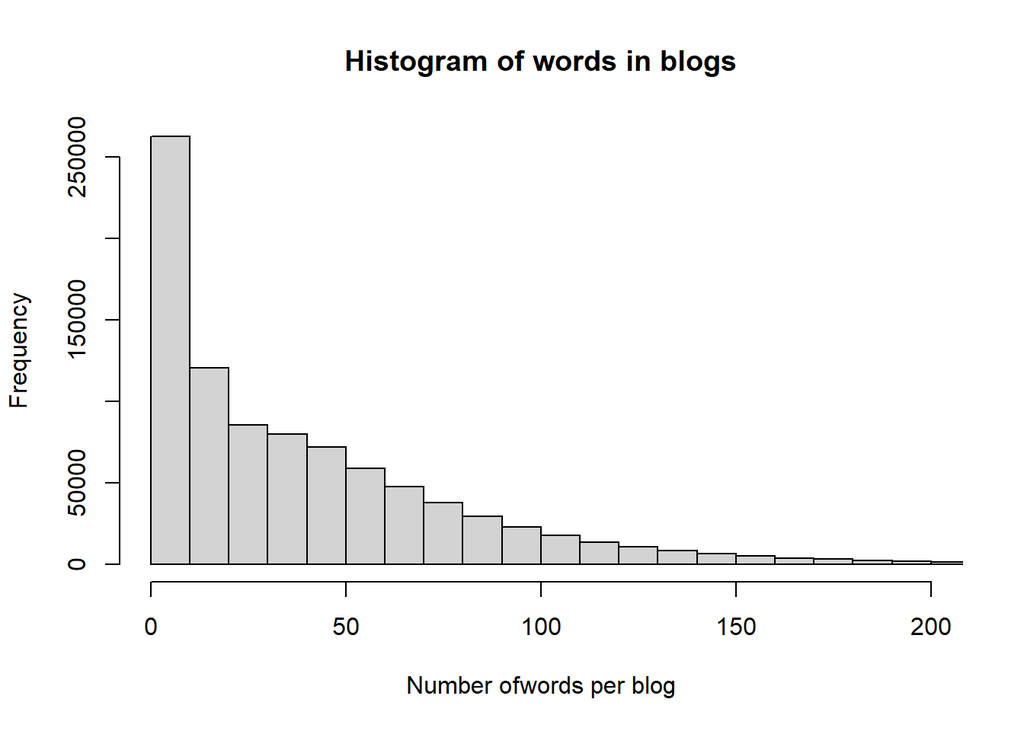

```r
hist(blogs.words,main="Histogram of words in blogs", xlab="Number ofwords per blog",breaks = 600,xlim=c(0,200))
```

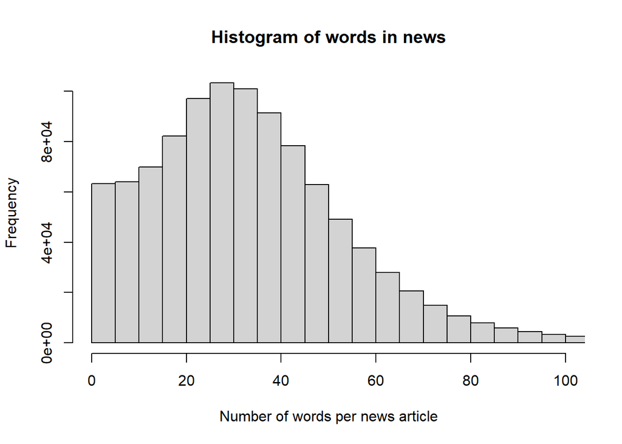

```r
# So, most of the blog posts have less than 50 Words.
hist(news.words,main="Histogram of words in news", xlab="Number of words per news article",breaks=300,xlim=c(0,100))
```

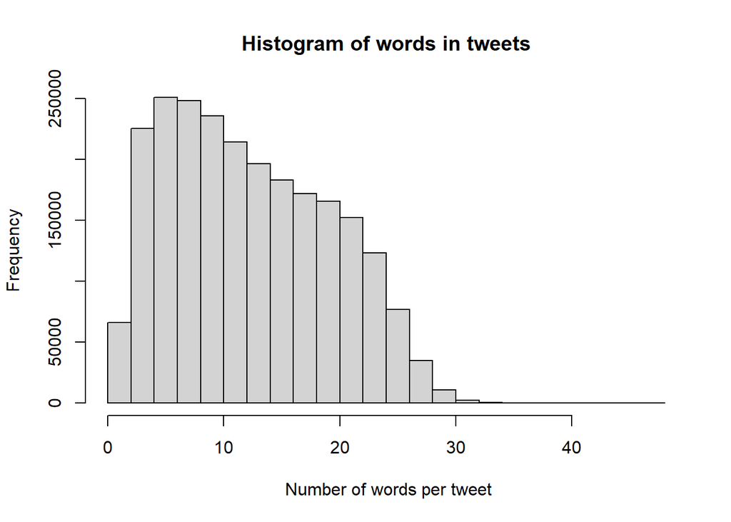

```r
# So, news with less than 100 words are something different. the most common in a news text is top have a text between 20 and 40 words.
hist(twitter.words,main="Histogram of words in tweets",xlab = " Number of words per tweet",breaks=20)
```

```r
# The way tweet varies is different. For starters, the longest tweet allowed is 140 characters.Measured in words, the largest tweet in the data is 47 words long.
# Almost all tweets have less than 30 words and the higher concentration is around 8 words per tweet.
```

## Ngram Tokenization

We have a clean dataset need to convert it to a format that is useful for NaturalLanguageProcessing(NLP). RWeka package will be used to develop Tokenization to create unigram,bigram and trigram. Document Term Matrix is created for the corpus.

```r
library(tm)
library(rJava)
library(RWeka)
library(ngram)

Unigram <- function(x) NGramTokenizer(x, Weka_control(min=1,max=1))
Bigram <- function(x) NGramTokenizer(x, Weka_control(min=2,max=2))
Trigram <- function(x) NGramTokenizer(x,Weka_control(min=3,max=3))

Unigrams <- DocumentTermMatrix(corpus, control = list(tokenize=Unigram))
Bigrams <- DocumentTermMatrix(corpus, control = list(tokenize=Bigram))
Trigrams <- DocumentTermMatrix(corpus, control = list(tokenize=Trigram))

Unigrams
```

```
## <<DocumentTermMatrix (documents: 33365, terms: 42646)>>
## Non-/sparse entries: 337905/1422545885
## Sparsity           : 100%
## Maximal term length: 50
## Weighting          : term frequency (tf)
```

```r
Bigrams
```

```
## <<DocumentTermMatrix (documents: 33365, terms: 287566)>>
## Non-/sparse entries: 337593/9594301997
## Sparsity           : 100%
## Maximal term length: 58
## Weighting          : term frequency (tf)
```

```r
Trigrams
```

```
## <<DocumentTermMatrix (documents: 33365, terms: 305206)>>
## Non-/sparse entries: 307564/10182890626
## Sparsity           : 100%
## Maximal term length: 64
## Weighting          : term frequency (tf)
```

## Conclusion

This compeltes initial Exploratory Data Analysis. The next step will be to build a predictive algorithm that uses an n-gram model with a frequency lookup similar to the analysis above. The algorithm will then be deployed in a Shinhy app and will suggest the most likely next word after a phrase is typed.